# BDA507 Term Project

## Dost Karaahmetli

### Foreword

With this report I will try to make explanatory data analysis on the European Soccer Database, as well as trying to answer two interesting questions and making inferences about them.

For this purpose, I decided to extract four datasets from the SQLite database;

- Country
- League
- Match
- Player Attributes (to be analysed seperately)

I will try to answer the following research questions:

- Is there really a so called home advantage?
- What are the most important skills (attributes) contributing to the overall rating of a player?

## A. Dataset and Pre-processing

**Dataset: European Soccer Database** *https://www.kaggle.com/hugomathien/soccer*

Some facts about the dataset:

- +25,000 matches
- +10,000 players
- 11 European Countries with their lead championship
- Seasons 2008 to 2016
- Players and Teams' attributes* sourced from EA Sports' FIFA video game series, including the weekly updates
- Detailed match events (goal types, possession, corner, cross, fouls, cards etc...) for +10,000 matches

### Import and Load Data

```python
import numpy as np
import pandas as pd
import sqlite3
import seaborn as sns
import matplotlib.pyplot as plt
```

```python
con = sqlite3.connect(r'C:\Users\dostk\Desktop\BDA\First Trimester\507 - Introduction to Computer Programming (Python)\TermProject\DataSet\database.sqlite')
cursor = con.cursor()
table_names = cursor.execute("SELECT name FROM sqlite_master WHERE type='table';")
print(cursor.fetchall())
```

```
[('sqlite_sequence',), ('Player_Attributes',), ('Player',), ('Match',), ('League',), ('Country',), ('Team',), ('Team_Attributes',)]
```

Load data: Read all (except Team, Player, Team_Attributes) sql tables into data frames.

Player_Attributes table will be loaded when needed...

```python
pd.read_sql("SELECT * FROM sqlite_master WHERE type='table';", con)
matches = pd.read_sql_query("SELECT * FROM Match", con)
leagues = pd.read_sql_query("SELECT * FROM League", con)
countries = pd.read_sql_query("SELECT * FROM Country", con)
```

### Pre-processing and Exploring dataset

Select Top 5 Countries/Leagues and merge:

```python
selected_countries = ['England','France','Germany','Italy','Spain']
countries = countries[countries.name.isin(selected_countries)]
leagues = countries.merge(leagues,on='id',suffixes=('', '_y'))
legues = leagues.drop("id",axis = 1)
leagues = leagues.rename(columns={'name':"country", 'name_y':"league"})
```

View Tables:

```python
leagues
```

|  | id | country | country_id | league |
| --- | --- | --- | --- | --- |
| 0 | 1729 | England | 1729 | England Premier League |
| 1 | 4769 | France | 4769 | France Ligue 1 |
| 2 | 7809 | Germany | 7809 | Germany 1. Bundesliga |
| 3 | 10257 | Italy | 10257 | Italy Serie A |
| 4 | 21518 | Spain | 21518 | Spain LIGA BBVA |

```python
matches = matches[['id', 'country_id', 'league_id', 'season', 'stage', 'date',
                   'match_api_id', 'home_team_api_id', 'away_team_api_id',
                    'home_team_goal', 'away_team_goal']]
```

Column 'date' in Matches Table is a string. Convert to datetime format:

```python
matches['date'] = pd.to_datetime(matches['date'])
```

```python
matches.head()
```

|  | id | country_id | league_id | season | stage | date | match_api_id | home_team_api_id | away_team_api_id | home_team_goal | away_team_goal |
| --- | --- | --- | --- | --- | --- | --- | --- | --- | --- | --- | --- |
| 0 | 1 | 1 | 1 | 2008/2009 | 1 | 2008-08-17 | 492473 | 9987 | 9993 | 1 | 1 |
| 1 | 2 | 1 | 1 | 2008/2009 | 1 | 2008-08-16 | 492474 | 10000 | 9994 | 0 | 0 |
| 2 | 3 | 1 | 1 | 2008/2009 | 1 | 2008-08-16 | 492475 | 9984 | 8635 | 0 | 3 |
| 3 | 4 | 1 | 1 | 2008/2009 | 1 | 2008-08-17 | 492476 | 9991 | 9998 | 5 | 0 |
| 4 | 5 | 1 | 1 | 2008/2009 | 1 | 2008-08-16 | 492477 | 7947 | 9985 | 1 | 3 |

**Data Wrangling:**

```python
leagues.info()
```

```
<class 'pandas.core.frame.DataFrame'>
Int64Index: 5 entries, 0 to 4
Data columns (total 4 columns):
id            5 non-null int64
country       5 non-null object
country_id    5 non-null int64
league        5 non-null object
dtypes: int64(2), object(2)
memory usage: 200.0+ bytes
```

```python
matches.info()
```

```
<class 'pandas.core.frame.DataFrame'>
RangeIndex: 25979 entries, 0 to 25978
Data columns (total 11 columns):
id                  25979 non-null int64
country_id          25979 non-null int64
league_id           25979 non-null int64
season              25979 non-null object
stage               25979 non-null int64
date                25979 non-null datetime64[ns]
match_api_id        25979 non-null int64
home_team_api_id    25979 non-null int64
away_team_api_id    25979 non-null int64
home_team_goal      25979 non-null int64
away_team_goal      25979 non-null int64
dtypes: datetime64[ns](1), int64(9), object(1)
memory usage: 2.2+ MB
```

```python
merged_data = leagues.merge(matches,left_on="country_id",right_on="country_id",how="inner")
merged_data = merged_data.drop(columns = ['country_id', 'league_id'])
merged_data.shape
```

```
(14585, 12)
```

```python
merged_data.nunique()
```

```
id_x                    5
country                 5
league                  5
id_y                14585
season                  8
stage                  38
date                 1363
match_api_id        14585
home_team_api_id      164
away_team_api_id      164
home_team_goal         11
away_team_goal         10
dtype: int64
```

```python
merged_data.isnull().sum()
```

```
id_x                0
country             0
league              0
id_y                0
season              0
stage               0
date                0
match_api_id        0
home_team_api_id    0
away_team_api_id    0
home_team_goal      0
away_team_goal      0
dtype: int64
```

**Pre-processing Notes:**

- I have left the "Players" and "Player_Attributes" dataframes out for mow. I'll use them for further analysis.
- The other dataframes (Country, League, Match and Team) are pretty clean; no duplicates nor null values.
- After merging the dataframes, I ended up with 14585 rows (of unique matches), 5 leagues and 8 seasons.
- The values in dates in column in matches dataframe were strings when imported, I converted this column to datetime format.

## B. EDA and Visualisation

**Is there really such a thing as "Home Advantage"?**

```python
home_away_df = merged_data[["home_team_goal", "away_team_goal"]]
home_away_df.describe()
```

|  | home_team_goal | away_team_goal |
| --- | --- | --- |
| count | 14585.000000 | 14585.000000 |
| mean | 1.539184 | 1.140075 |
| std | 1.289485 | 1.129409 |
| min | 0.000000 | 0.000000 |
| 25% | 1.000000 | 0.000000 |
| 50% | 1.000000 | 1.000000 |
| 75% | 2.000000 | 2.000000 |
| max | 10.000000 | 9.000000 |

Average goals per match for home teams is 1.54, whereas it's 1.14 for visiting teams.

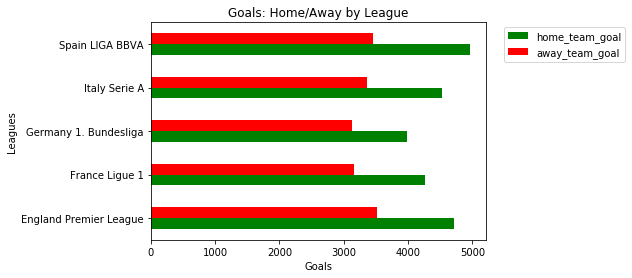

```python
merged_data.groupby("league").agg({"home_team_goal":"sum","away_team_goal":"sum"}).plot(kind="barh", color=('green', 'red'))
plt.title("Goals: Home/Away by League")
plt.legend(loc=(1.04,0))
plt.legend(bbox_to_anchor=(1.04,1), loc="best")
plt.xlabel("Goals")
plt.ylabel("Leagues")
plt.show()
```

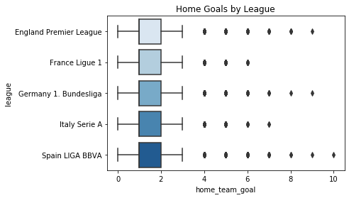

```python
sns.boxplot(x = merged_data["home_team_goal"], y = merged_data["league"], palette="Blues")
plt.title("Home Goals by League")
plt.show()
```

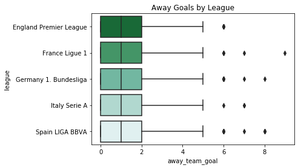

```python
sns.boxplot(x = merged_data["away_team_goal"], y = merged_data["league"], palette="BuGn_r")
plt.title("Away Goals by League")
plt.show()
```

Home teams score more than away teams in all of the 5 top leagues.

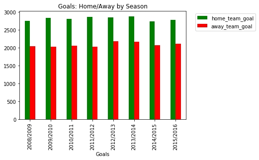

```python
merged_data.groupby("season").agg({"home_team_goal":"sum","away_team_goal":"sum"}).plot(kind="bar", color=('green', 'red'))
plt.title("Goals: Home/Away by Season")
plt.legend(loc=(1.04,0))
plt.legend(bbox_to_anchor=(1.04,1), loc="best")
plt.xlabel("Goals")
plt.show()
```

Home teams score more than away teams in all of the 8 seasons.

```python
goal_dif = matches['home_team_goal'] - matches['away_team_goal']
merged_data['goal_dif'] = goal_dif
merged_data.shape
```

```
(14585, 13)
```

```python
print("Home teams have scored {} more goals than visitors in all matches recorded in the database."
      .format(sum(merged_data['goal_dif'])))
```

```
Home teams have scored 5790 more goals than visitors in all matches recorded in the database.
```

```python
merged_data.head()
```

|  | id_x | country | league | id_y | season | stage | date | match_api_id | home_team_api_id | away_team_api_id | home_team_goal | away_team_goal | goal_dif |
| --- | --- | --- | --- | --- | --- | --- | --- | --- | --- | --- | --- | --- | --- |
| 0 | 1729 | England | England Premier League | 1729 | 2008/2009 | 1 | 2008-08-17 | 489042 | 10260 | 10261 | 1 | 1 | 0 |
| 1 | 1729 | England | England Premier League | 1730 | 2008/2009 | 1 | 2008-08-16 | 489043 | 9825 | 8659 | 1 | 0 | 0 |
| 2 | 1729 | England | England Premier League | 1731 | 2008/2009 | 1 | 2008-08-16 | 489044 | 8472 | 8650 | 0 | 1 | -3 |
| 3 | 1729 | England | England Premier League | 1732 | 2008/2009 | 1 | 2008-08-16 | 489045 | 8654 | 8528 | 2 | 1 | 5 |
| 4 | 1729 | England | England Premier League | 1733 | 2008/2009 | 1 | 2008-08-17 | 489046 | 10252 | 8456 | 4 | 2 | -2 |

```python
merged_data.columns.tolist()
```

```
['id_x',
 'country',
 'league',
 'id_y',
 'season',
 'stage',
 'date',
 'match_api_id',
 'home_team_api_id',
 'away_team_api_id',
 'home_team_goal',
 'away_team_goal',
 'goal_dif']
```

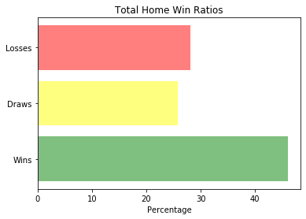

```python
result = merged_data['goal_dif']
games = len(result)
win = sum([i > 0 for i in result])
draw = sum([i == 0 for i in result])
loss = games-(win + draw)

perc = [win/games*100, draw/games*100, loss/games*100]
labels = ["Wins","Draws","Losses"]
y_pos = np.arange(len(perc))
plt.barh(y_pos, perc, align='center', color=['green', 'yellow', 'red'], alpha=0.5)
plt.yticks(y_pos, labels)
plt.xlabel(r'Percentage')
plt.title('Total Home Win Ratios')
plt.show()
```

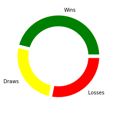

```python
perc = [win/games*100, draw/games*100, loss/games*100]
my_circle = plt.Circle( (0,0), 0.7, color='white')
plt.pie(perc, labels = ["Wins","Draws","Losses"], colors=['green', 'yellow', 'red'],
        wedgeprops = { 'linewidth' : 7, 'edgecolor' : 'white' })
p = plt.gcf()
p.gca().add_artist(my_circle)
plt.show()
```

```python
r_perc = np.around(perc, decimals=1)
print('Home wins percentage is {0}, whereas loss percentage is {1}.'.format(r_perc[0], r_perc[2]))
```

```
Home wins percentage is 46.1, whereas loss percentage is 28.1.
```

Therefore, we can state that, there seems to be a significant likelihood of home team win in a given game.

We will see if this is statistically true in our further analysis.

```python
games_by_goal_diff = merged_data.groupby(['goal_dif']).count()['id_x']
games_by_goal_diff
```

```
goal_dif
-9        1
-7        4
-6       13
-5       42
-4      156
-3      450
-2     1212
-1     2221
 0     3761
 1     3098
 2     2085
 3      966
 4      400
 5      115
 6       42
 7       13
 8        5
 10       1
Name: id_x, dtype: int64
```

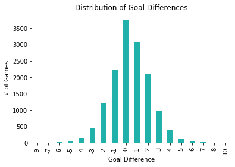

```python
games_by_goal_diff.plot(kind='bar', color='lightseagreen')
plt.xlabel('Goal Difference')
plt.ylabel('# of Games')
plt.title('Distribution of Goal Differences')
plt.show()
```

```python
onegoal = np.around(100*(games_by_goal_diff[-1] + games_by_goal_diff[1])/len(merged_data['id_y']), 1)
print('{0}% of matches were decided by only one goal.'.format(onegoal))
```

```
36.5% of matches were decided by only one goal.
```

```python
mean_goal_dif = merged_data.groupby("league").agg({"goal_dif":"mean"})
mean_goal_dif
```

| league | goal_dif |
| --- | --- |
| England Premier League | 0.425329 |
| France Ligue 1 | 0.357237 |
| Germany 1. Bundesliga | 0.359477 |
| Italy Serie A | 0.390786 |
| Spain LIGA BBVA | 0.444737 |

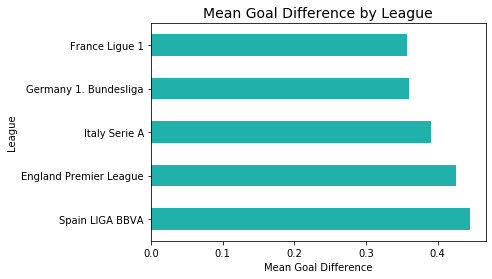

```python
ax = mean_goal_dif.sort_values(by='goal_dif', ascending=False).plot.barh(legend=False, color='lightseagreen')
ax.set_xlabel("Mean Goal Difference")
ax.set_ylabel("League")
ax.grid(False)
plt.title('Mean Goal Difference by League', fontsize=14)
```

### Key Takeaways:

- There is a difference of 0.4 goals between means of goals by home and away teams in favor of home team.
- Teams win an average of 46% of home games compared with 28% of away games.
- The home advantage exists in all of the countries; most in Spain LIGA BBVA and least in France Ligue 1.
- Also, home advantage is present for all the seasons.

As stated above, Exploratory Data Analysis suggest that "Home Advantage" really exist.

## C. Inferential Statistics

Playing at home is almost certainly an advantage. Otherwise, the mean goal difference (calculated above) would be zero. However, it is 0.4 for our dataset.

I'd like to run a one sample t-test to compare the mean goal difference of our sample (0.4), to the expected mean goal difference without home advantage (0).

```python
merged_data['goal_dif'].describe()
```

```
count    14585.000000
mean         0.396983
std          1.758286
min         -9.000000
25%         -1.000000
50%          0.000000
75%          1.000000
max         10.000000
Name: goal_dif, dtype: float64
```

```python
from scipy import stats
```

```python
stats.ttest_1samp(merged_data['goal_dif'], 0)
```

```
Ttest_1sampResult(statistic=27.266899337153152, pvalue=1.0269082975202508e-159)
```

H0 -> Average goal difference between home and away goals does not differ from the expected average difference (0).

- H0: µgd = 0 Ha -> Average goal difference between home and away goals is larger than 0.
- Ha: µgd > 0

Reject H0 if p-value ≤ α P-value is so small that we don't even have to look at the t-Table. Thus, we reject H0.

### Conclusion:

We have strong evidence that average difference between home and away goals differ from the expected average difference, in favor of home goals. (LoS = 0.05, p-value = 1.027e-159)

This difference is considered to be statistically significant, so we can say that there is indeed an advantage for teams playing in their home stadium.

## D. Inferential Statistics: Player Stats Analysis

### Wrangling and exploring data

```python
player_atts = pd.read_sql_query("SELECT * FROM Player_Attributes", con)
```

```python
player_atts.head()
```

|  | id | player_fifa_api_id | player_api_id | date | overall_rating | potential | preferred_foot | attacking_work_rate | defensive_work_rate | crossing | ... | vision | penalties | marking | standing_tackle | sliding_tackle | gk_diving | gk_handling | gk_kicking | gk_positioning | gk_reflexes |
| --- | --- | --- | --- | --- | --- | --- | --- | --- | --- | --- | --- | --- | --- | --- | --- | --- | --- | --- | --- | --- | --- |
| 0 | 1 | 218353 | 505942 | 2016-02-18 00:00:00 | 67.0 | 71.0 | right | medium | medium | 49.0 | ... | 54.0 | 48.0 | 65.0 | 69.0 | 69.0 | 6.0 | 11.0 | 10.0 | 8.0 | 8.0 |
| 1 | 2 | 218353 | 505942 | 2015-11-19 00:00:00 | 67.0 | 71.0 | right | medium | medium | 49.0 | ... | 54.0 | 48.0 | 65.0 | 69.0 | 69.0 | 6.0 | 11.0 | 10.0 | 8.0 | 8.0 |
| 2 | 3 | 218353 | 505942 | 2015-09-21 00:00:00 | 62.0 | 66.0 | right | medium | medium | 49.0 | ... | 54.0 | 48.0 | 65.0 | 66.0 | 69.0 | 6.0 | 11.0 | 10.0 | 8.0 | 8.0 |
| 3 | 4 | 218353 | 505942 | 2015-03-20 00:00:00 | 61.0 | 65.0 | right | medium | medium | 48.0 | ... | 53.0 | 47.0 | 62.0 | 63.0 | 66.0 | 5.0 | 10.0 | 9.0 | 7.0 | 7.0 |
| 4 | 5 | 218353 | 505942 | 2007-02-22 00:00:00 | 61.0 | 65.0 | right | medium | medium | 48.0 | ... | 53.0 | 47.0 | 62.0 | 63.0 | 66.0 | 5.0 | 10.0 | 9.0 | 7.0 | 7.0 |

5 rows × 42 columns

```python
sum(player_atts.duplicated())
```

```
0
```

```python
player_atts.isnull().sum()
```

```
id                        0
player_fifa_api_id        0
player_api_id             0
date                      0
overall_rating          836
potential               836
preferred_foot          836
attacking_work_rate    3230
defensive_work_rate     836
crossing                836
finishing               836
heading_accuracy        836
short_passing           836
volleys                2713
dribbling               836
curve                  2713
free_kick_accuracy      836
long_passing            836
ball_control            836
acceleration            836
sprint_speed            836
agility                2713
reactions               836
balance                2713
shot_power              836
jumping                2713
stamina                 836
strength                836
long_shots              836
aggression              836
interceptions           836
positioning             836
vision                 2713
penalties               836
marking                 836
standing_tackle         836
sliding_tackle         2713
gk_diving               836
gk_handling             836
gk_kicking              836
gk_positioning          836
gk_reflexes             836
dtype: int64
```

I decided to remove "na"s, since we already have pretty big data. So, my analysis won't be effected too much.

```python
player_atts.dropna(axis=0, how='any', inplace=True)
```

```python
player_atts = player_atts.drop(columns=['player_fifa_api_id', 'player_api_id', 'id', 'date'])
```

I also would like to remove non-numeric columns, because I don't need them.

```python
player_atts = player_atts.drop(columns=['preferred_foot', 'attacking_work_rate', 'defensive_work_rate'])
```

```python
player_atts.shape
```

```
(180354, 35)
```

```python
player_atts.describe().T
```

|  | count | mean | std | min | 25% | 50% | 75% | max |
| --- | --- | --- | --- | --- | --- | --- | --- | --- |
| overall_rating | 180354.0 | 68.635317 | 7.027950 | 33.0 | 64.0 | 69.0 | 73.0 | 94.0 |
| potential | 180354.0 | 73.479457 | 6.581963 | 39.0 | 69.0 | 74.0 | 78.0 | 97.0 |
| crossing | 180354.0 | 55.142071 | 17.247231 | 1.0 | 45.0 | 59.0 | 68.0 | 95.0 |
| finishing | 180354.0 | 49.962136 | 19.041760 | 1.0 | 34.0 | 53.0 | 65.0 | 97.0 |
| heading_accuracy | 180354.0 | 57.263476 | 16.478716 | 1.0 | 49.0 | 60.0 | 68.0 | 98.0 |
| short_passing | 180354.0 | 62.486726 | 14.172493 | 3.0 | 57.0 | 65.0 | 72.0 | 97.0 |
| volleys | 180354.0 | 49.488927 | 18.252319 | 1.0 | 35.0 | 52.0 | 64.0 | 93.0 |
| dribbling | 180354.0 | 59.265755 | 17.741351 | 1.0 | 52.0 | 64.0 | 72.0 | 97.0 |
| curve | 180354.0 | 53.001408 | 18.245476 | 2.0 | 41.0 | 56.0 | 67.0 | 94.0 |
| free_kick_accuracy | 180354.0 | 49.392783 | 17.820262 | 1.0 | 36.0 | 50.0 | 63.0 | 97.0 |
| long_passing | 180354.0 | 57.084578 | 14.412035 | 3.0 | 49.0 | 59.0 | 67.0 | 97.0 |
| ball_control | 180354.0 | 63.453846 | 15.187692 | 5.0 | 59.0 | 67.0 | 73.0 | 97.0 |
| acceleration | 180354.0 | 67.709405 | 13.011580 | 10.0 | 61.0 | 69.0 | 77.0 | 97.0 |
| sprint_speed | 180354.0 | 68.101628 | 12.585984 | 12.0 | 62.0 | 69.0 | 77.0 | 97.0 |
| agility | 180354.0 | 65.995082 | 12.963670 | 11.0 | 58.0 | 68.0 | 75.0 | 96.0 |
| reactions | 180354.0 | 66.148297 | 9.145011 | 17.0 | 61.0 | 67.0 | 72.0 | 96.0 |
| balance | 180354.0 | 65.190082 | 13.076192 | 12.0 | 58.0 | 67.0 | 74.0 | 96.0 |
| shot_power | 180354.0 | 61.866474 | 16.129537 | 2.0 | 54.0 | 66.0 | 73.0 | 97.0 |
| jumping | 180354.0 | 66.977333 | 11.017828 | 14.0 | 60.0 | 68.0 | 74.0 | 96.0 |
| stamina | 180354.0 | 67.053401 | 13.200669 | 10.0 | 61.0 | 69.0 | 76.0 | 96.0 |
| strength | 180354.0 | 67.432477 | 12.085131 | 10.0 | 60.0 | 69.0 | 76.0 | 96.0 |
| long_shots | 180354.0 | 53.387560 | 18.370204 | 1.0 | 41.0 | 58.0 | 67.0 | 96.0 |
| aggression | 180354.0 | 60.946217 | 16.101618 | 6.0 | 51.0 | 64.0 | 73.0 | 97.0 |
| interceptions | 180354.0 | 51.897374 | 19.483338 | 1.0 | 34.0 | 56.0 | 68.0 | 96.0 |
| positioning | 180354.0 | 55.730730 | 18.458218 | 2.0 | 45.0 | 60.0 | 69.0 | 95.0 |
| vision | 180354.0 | 57.868176 | 15.152408 | 1.0 | 49.0 | 60.0 | 69.0 | 97.0 |
| penalties | 180354.0 | 54.933448 | 15.556645 | 2.0 | 45.0 | 57.0 | 67.0 | 96.0 |
| marking | 180354.0 | 46.757433 | 21.226730 | 1.0 | 25.0 | 50.0 | 66.0 | 94.0 |
| standing_tackle | 180354.0 | 50.354065 | 21.496289 | 1.0 | 29.0 | 56.0 | 69.0 | 95.0 |
| sliding_tackle | 180354.0 | 48.029342 | 21.592830 | 2.0 | 25.0 | 53.0 | 67.0 | 95.0 |
| gk_diving | 180354.0 | 14.696685 | 16.841454 | 1.0 | 7.0 | 10.0 | 13.0 | 94.0 |
| gk_handling | 180354.0 | 15.947786 | 15.841297 | 1.0 | 8.0 | 11.0 | 15.0 | 93.0 |
| gk_kicking | 180354.0 | 20.526304 | 21.143898 | 1.0 | 8.0 | 12.0 | 15.0 | 97.0 |
| gk_positioning | 180354.0 | 16.015043 | 16.070772 | 1.0 | 8.0 | 11.0 | 15.0 | 96.0 |
| gk_reflexes | 180354.0 | 16.325310 | 17.185450 | 1.0 | 8.0 | 11.0 | 15.0 | 96.0 |

```python
player_atts.head()
```

|  | overall_rating | potential | crossing | finishing | heading_accuracy | short_passing | volleys | dribbling | curve | free_kick_accuracy | ... | vision | penalties | marking | standing_tackle | sliding_tackle | gk_diving | gk_handling | gk_kicking | gk_positioning | gk_reflexes |
| --- | --- | --- | --- | --- | --- | --- | --- | --- | --- | --- | --- | --- | --- | --- | --- | --- | --- | --- | --- | --- | --- |
| 0 | 67.0 | 71.0 | 49.0 | 44.0 | 71.0 | 61.0 | 44.0 | 51.0 | 45.0 | 39.0 | ... | 54.0 | 48.0 | 65.0 | 69.0 | 69.0 | 6.0 | 11.0 | 10.0 | 8.0 | 8.0 |
| 1 | 67.0 | 71.0 | 49.0 | 44.0 | 71.0 | 61.0 | 44.0 | 51.0 | 45.0 | 39.0 | ... | 54.0 | 48.0 | 65.0 | 69.0 | 69.0 | 6.0 | 11.0 | 10.0 | 8.0 | 8.0 |
| 2 | 62.0 | 66.0 | 49.0 | 44.0 | 71.0 | 61.0 | 44.0 | 51.0 | 45.0 | 39.0 | ... | 54.0 | 48.0 | 65.0 | 66.0 | 69.0 | 6.0 | 11.0 | 10.0 | 8.0 | 8.0 |
| 3 | 61.0 | 65.0 | 48.0 | 43.0 | 70.0 | 60.0 | 43.0 | 50.0 | 44.0 | 38.0 | ... | 53.0 | 47.0 | 62.0 | 63.0 | 66.0 | 5.0 | 10.0 | 9.0 | 7.0 | 7.0 |
| 4 | 61.0 | 65.0 | 48.0 | 43.0 | 70.0 | 60.0 | 43.0 | 50.0 | 44.0 | 38.0 | ... | 53.0 | 47.0 | 62.0 | 63.0 | 66.0 | 5.0 | 10.0 | 9.0 | 7.0 | 7.0 |

5 rows × 35 columns

### Analysis of the data

- Correlation Between Attributes

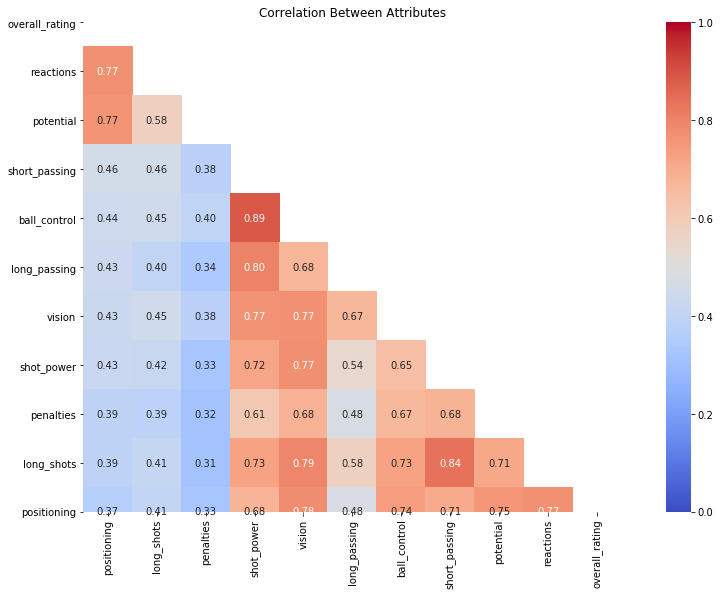

```python
corr = player_atts.corr()
cols = corr.nlargest(11, columns='overall_rating')['overall_rating'].index
corr_mtrx = np.corrcoef(player_atts[cols].values.T)
mask = np.zeros(corr_mtrx.shape, dtype=bool)
mask[np.triu_indices(len(mask))] = True
plt.figure(figsize=(16, 9))
sns.heatmap(corr_mtrx, cbar=True, cmap = 'coolwarm', annot=True, square = True, fmt='.2f',
            annot_kws={'size': 10}, vmin = 0, vmax = 1,
            yticklabels = cols.values, xticklabels = cols.values[::-1], mask = mask)
plt.title("Correlation Between Attributes")
plt.show()
```

Top 10 Attributes contributing to the Overall Rating of a Player:

```python
corr_rate = corr["overall_rating"].sort_values(ascending=False)
corr_rate10 = corr_rate.head(11)
corr_rate10 = corr_rate10.drop(['overall_rating'])
corr_rate10 = pd.DataFrame(corr_rate10)
corr_rate10.style
```

|  | overall_rating |
| --- | --- |
| reactions | 0.771856 |
| potential | 0.765435 |
| short_passing | 0.458243 |
| ball_control | 0.443991 |
| long_passing | 0.434525 |
| vision | 0.431493 |
| shot_power | 0.428053 |
| penalties | 0.392715 |
| long_shots | 0.392668 |
| positioning | 0.368978 |

### Conclusion:

To determine which player attribute correspond to a higher overall FIFA rating, I've used the **"corr"** function and plotted it to display a matrix to see the correlations between attributes. There are two significant strong correlations which effects overall rating of a player; *"Reactions"* and *"Potential"*...

In fact, I expected to see more attributes with more correlation coefficients.